# Benefit Threat to City Solvency

### 2. Total Pension Liability Per Capita

The difference in the reported pension liability and our own valuations scaled by population size are illustrated in Figure 2 below. Similar to OPEB, we provide per capita measures to present city residents with a better idea of their city’s pension financial burden and how it compares with that of other cities. The average reported total pension liability per capita was **$38,782** while the average standardized total pension liability per capita was **$59,531**.

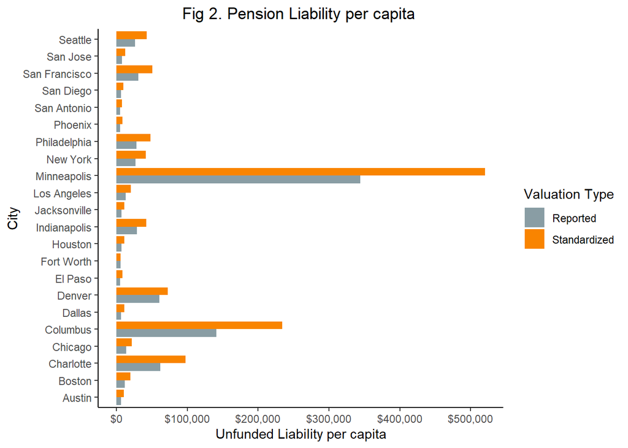

While New York has the largest unfunded pension liability in terms of total dollar amount, the City of Minneapolis has the largest one, about $520,000 in terms of dollars per capita.

### 3. Share of revenue

The share or proportion of a city’s governmental fund revenues used to cover the pension expense in 2017 is illustrated in Figure 3. This further provides users with another alternative to compare cities regarding their pension financial burden. The average share of revenue was **31.94%** with a low of **0.85%** for Seattle and a high of **73.64%** for Dallas.

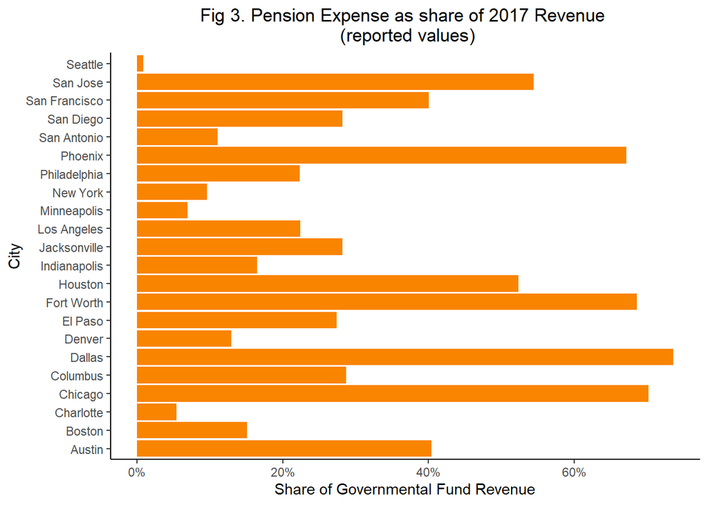